# All Countries Environmental Data

## Method: PCA

Principal component analysis (PCA), part of descriptive analytics, is used to analyze one table of quantitative data, specifically useful for *high dimensional data* and comparitively lesser data rows. PCA mixes the input variables to give new variables, called principal components. The first principal component is the line of best fit. It is the line that maximizes the inertia (similar to variance) of the cloud of data points. Subsequent components are defined as orthogonal to previous components, and maximize the remaining inertia.

PCA gives one map for the rows (called factor scores), and one map for the columns (called loadings). These 2 maps are related, because they both are described by the same components. However, these 2 maps project different kinds of information onto the components, and so they are *interpreted differently*. Factor scores are the coordinates of the row observations and Loadings describe the column variables. Both can be interpreted through their distance from origin. However, Factor scores are also interpreted by the distances between them and Loadings interpreted by the angle between them.

The distance from the origin is important in both maps, because squared distance from the mean is inertia (variance, information; see sum of squares as in ANOVA/regression). Because of the Pythagorean Theorem, the total information contributed by a data point (its squared distance to the origin) is also equal to the sum of its squared factor scores.

With both Factor and Loadings maps combined we can interpret which grouping criteria of rows of data is most impacted by which columns. This can interpreted visually by observing which a factors and loadings on a particular component and the distance on this component.

PCA also helps in *dimensionality reduction*. Using SVD, we get eigen values arranged in descending order in the diagonal matrix. We can simply ignore the lower eigen values to reduce dimensions. We can also take help of SCREE plot to visually analyze importance of eigen values.

## Dataset

- Data: Measurements of environment conditions in Countries
- Rows: There are 137 observations, 1 for each country.
- Columns: Total 29 variables
- Qualitative: Country (nominal), Happiness (Ordinal).
- Quantitative: Aspect, Slope Crop Land, Tree Canopy Wind Cloud & Multiple variables for Temp & Rain
- Summary of Data

```r
summary(country_env_df)
```

```
        Country    Happiness_Rank accessibility_to_cities   elevation            aspect           slope        cropland_cover     tree_canopy_cover
 Afghanistan:  1   VH:34          Min.   :   0.969        Min.   :   8.319   Min.   : 94.24   Min.   :0.0000   Min.   : 0.00553   Min.   : 0.000
 Albania    :  1   H :69          1st Qu.:  55.216        1st Qu.: 251.926   1st Qu.:168.27   1st Qu.:0.1592   1st Qu.: 6.18871   1st Qu.: 4.926
 Algeria    :  1   U :34          Median : 122.848        Median : 425.131   Median :176.14   Median :0.5200   Median :19.97215   Median :16.579
 Angola     :  1                  Mean   : 321.889        Mean   : 603.987   Mean   :177.11   Mean   :0.7470   Mean   :24.28494   Mean   :19.109
 Argentina  :  1                  3rd Qu.: 338.201        3rd Qu.: 814.622   3rd Qu.:186.50   3rd Qu.:1.1985   3rd Qu.:36.14503   3rd Qu.:31.197
 Armenia    :  1                  Max.   :3220.715        Max.   :2962.817   Max.   :245.34   Max.   :3.6984   Max.   :77.52802   Max.   :60.085
 (Other)    :131
 isothermality   rain_coldestQuart   rain_driestMonth  rain_driestQuart rain_mean_annual  rain_seasonailty rain_warmestQuart rain_wettestMonth
 Min.   :19.35   Min.   :   0.0312   Min.   :  0.000   Min.   :  0.00   Min.   :  14.16   Min.   : 11.16   Min.   :   0.00   Min.   :  3.757
 1st Qu.:31.83   1st Qu.:  69.6743   1st Qu.:  2.611   1st Qu.: 14.01   1st Qu.: 501.66   1st Qu.: 35.77   1st Qu.:  99.63   1st Qu.: 79.354
 Median :44.35   Median : 144.7110   Median : 16.807   Median : 67.22   Median : 847.35   Median : 59.71   Median : 217.20   Median :124.978
 Mean   :48.64   Mean   : 217.7677   Mean   : 27.408   Mean   : 97.34   Mean   :1033.53   Mean   : 62.51   Mean   : 267.52   Mean   :173.078
 3rd Qu.:65.48   3rd Qu.: 271.8047   3rd Qu.: 40.790   3rd Qu.:141.79   3rd Qu.:1486.49   3rd Qu.: 87.52   3rd Qu.: 366.79   3rd Qu.:270.387
 Max.   :87.00   Max.   :1271.9904   Max.   :157.769   Max.   :537.83   Max.   :2972.14   Max.   :144.51   Max.   :1195.09   Max.   :537.011

 rain_wettestQuart  temp_annual_range temp_coldestQuart  temp_diurnal_range temp_driestQuart  temp_max_warmestMonth temp_mean_annual temp_min_coldestMonth
 Min.   :   8.929   Min.   : 9.275    Min.   :-24.7437   Min.   : 6.154     Min.   :-19.847   Min.   :16.43         Min.   :-6.832   Min.   :-30.679
 1st Qu.: 213.785   1st Qu.:16.848    1st Qu.:  0.4906   1st Qu.: 9.114     1st Qu.:  8.557   1st Qu.:25.50         1st Qu.: 9.789   1st Qu.: -4.007
 Median : 338.736   Median :25.775    Median : 13.0249   Median :10.622     Median : 19.985   Median :30.72         Median :19.845   Median :  5.713
 Mean   : 454.883   Mean   :25.110    Mean   : 10.7980   Mean   :10.927     Mean   : 16.240   Mean   :29.98         Mean   :17.215   Mean   :  4.872
 3rd Qu.: 716.121   3rd Qu.:30.863    3rd Qu.: 21.5560   3rd Qu.:12.612     3rd Qu.: 24.828   3rd Qu.:34.05         3rd Qu.:24.395   3rd Qu.: 15.195
 Max.   :1441.200   Max.   :50.631    Max.   : 26.2576   Max.   :16.269     Max.   : 35.217   Max.   :43.84         Max.   :28.250   Max.   : 22.202

 temp_seasonality  temp_warmestQuart temp_wettestQuart      wind         cloudiness
 Min.   :  3.001   Min.   : 9.504    Min.   : 1.567    Min.   :1.203   Min.   : 50.36
 1st Qu.: 16.811   1st Qu.:18.643    1st Qu.:11.657    1st Qu.:2.202   1st Qu.:154.88
 Median : 48.591   Median :24.352    Median :19.084    Median :2.796   Median :199.37
 Mean   : 48.573   Mean   :23.185    Mean   :18.198    Mean   :2.927   Mean   :190.10
 3rd Qu.: 71.384   3rd Qu.:27.270    3rd Qu.:24.748    3rd Qu.:3.586   3rd Qu.:234.12
 Max.   :145.221   Max.   :35.217    Max.   :31.853    Max.   :4.724   Max.   :322.19
```

- Research Question

How do the 137 countries differ on these variables?

|  | Happiness_Rank | accessibility_to_cities | elevation | aspect | slope | cropland_cover | tree_canopy_cover | isothermality | rain_coldestQuart | rain_driestMonth | rain_driestQuart | rain_seasonailty | rain_warmestQuart | rain_wettestMonth | rain_wettestQuart | temp_annual_range | temp_coldestQuart | temp_diurnal_range | temp_driestQuart | temp_max_warmestMonth | temp_mean_annual | temp_min_coldestMonth | temp_warmestQuart | temp_wettestQuart | wind | cloudiness |
| --- | --- | --- | --- | --- | --- | --- | --- | --- | --- | --- | --- | --- | --- | --- | --- | --- | --- | --- | --- | --- | --- | --- | --- | --- | --- | --- |
| Afghanistan(U) | 153 | 317.71575 | 1831.7444 | 201.4298 | 1.5156001 | 9.511846 | 0.3746726 | 35.90442 | 128.718360 | 1.7224832 | 8.300540 | 91.62876 | 12.689584 | 67.83925 | 175.8160 | 40.26161 | -0.2613516 | 14.724698 | 21.1203287 | 31.95010 | 11.53331 | -8.3115067 | 22.67524 | 3.947660 | 3.432747 | 114.22898 |
| Albania(H) | 95 | 73.83086 | 651.8155 | 192.1303 | 1.8900753 | 23.346087 | 12.8046289 | 33.16941 | 392.508789 | 40.0884801 | 138.154620 | 38.54663 | 138.334670 | 159.04607 | 435.8747 | 27.08155 | 3.5798958 | 9.114174 | 19.5732059 | 26.27564 | 11.46749 | -0.8059126 | 19.57742 | 5.267450 | 2.472694 | 181.13111 |
| Algeria(H) | 68 | 1212.79982 | 556.7583 | 184.9747 | 0.1708615 | 3.690864 | 0.1766562 | 40.29895 | 25.290778 | 0.9349921 | 6.088662 | 67.08149 | 9.508621 | 13.36623 | 33.2941 | 36.49031 | 13.1515534 | 14.872674 | 26.9210724 | 41.54823 | 22.96395 | 5.0579265 | 32.45083 | 20.813229 | 4.025770 | 90.67439 |
| Angola(U) | 137 | 378.20239 | 1061.4790 | 174.2569 | 0.1926286 | 2.794476 | 19.8701092 | 64.33239 | 8.054832 | 0.2601221 | 4.430197 | 91.53816 | 318.535618 | 202.19713 | 524.2807 | 21.48916 | 18.7935162 | 13.845249 | 18.8668818 | 31.03791 | 21.61187 | 9.5487517 | 23.28857 | 22.758982 | 2.164405 | 187.51704 |
| Argentina(VH) | 30 | 209.21958 | 682.7993 | 145.0314 | 0.6238553 | 21.962504 | 8.8336096 | 49.85147 | 79.087675 | 17.1832114 | 60.486305 | 48.32124 | 183.138160 | 79.21689 | 211.7121 | 26.77336 | 8.0238906 | 13.461877 | 11.0949601 | 28.21619 | 14.20719 | 1.4428340 | 20.17117 | 16.477629 | 4.270904 | 159.00653 |
| Armenia(U) | 127 | 97.29452 | 1850.4830 | 183.5375 | 2.3188956 | 21.338266 | 6.9929146 | 32.42359 | 69.674299 | 20.0054896 | 67.223098 | 46.50160 | 127.161681 | 86.25816 | 213.7846 | 34.82843 | -4.5577218 | 11.433959 | -0.5852048 | 24.35806 | 6.16530 | -10.4703703 | 16.19944 | 9.369816 | 1.968253 | 191.76167 |

- PCA

```r
country_env_pca <- epPCA(DATA = country_env_df_for_pca, center = TRUE, scale = 'SS1', DESIGN = country_env_df$Happiness_Rank, graphs = FALSE)
```

## Results

There are multiple variables representing rain and Temp. Hence, for analysis purposes, lets choose annual mean for Rain and Temp.

### Correlation Plot

Visually analyze multicollinearity in the system

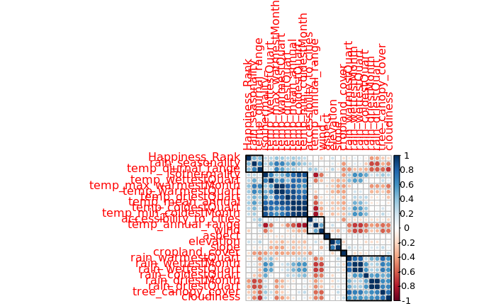

```r
corr_result = cor(country_env_df_for_corr)
corrplot(corr_result,order = 'hclust', addrect = 7)
```

### Scree Plot

Gives amount of information explained by corresponding component.

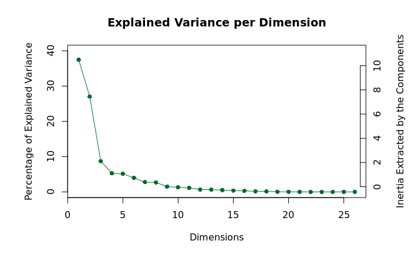

```r
PTCA4CATA::PlotScree(ev = country_env_pca$ExPosition.Data$eigs)
```

### Factor Scores

Since the spreed of the data is not clearly differentiated by both components, let’s try to visualize the means of each happiness category.

- Ploting only mean points for each happiness category.

```r
country_env_pca_mean = aggregate(x=country_env_pca$ExPosition.Data$fi, by = split(col, col(col)), FUN = mean)
rownames(country_env_pca_mean) <- c('Happy', 'Happier', 'Happiest')

country_env_pca_mean <- country_env_pca_mean[-1]
country_env_pca_mean
```

|  | V1 | V2 | V3 | V4 | V5 | V6 | V7 | V8 | V9 | V10 | V11 | V12 | V13 | V14 | V15 | V16 | V17 | V18 | V19 | V20 | V21 | V22 | V23 | V24 | V25 | V26 |
| --- | --- | --- | --- | --- | --- | --- | --- | --- | --- | --- | --- | --- | --- | --- | --- | --- | --- | --- | --- | --- | --- | --- | --- | --- | --- | --- |
| Happy | -0.09692735 | -0.14448774 | 0.04342049 | 0.013249031 | 0.007104670 | 0.012376077 | 0.040965921 | 0.004208648 | -0.003173913 | 0.002205249 | -0.0003611909 | -0.004559614 | -0.0038234190 | -0.0044097884 | -0.0044090457 | -0.0030732386 | 0.001576150 | -0.003889618 | -0.0026904091 | -0.0014777280 | -0.0012481974 | 5.806244e-04 | 0.0002489842 | 0.0001654221 | 3.056739e-05 | -1.922966e-05 |
| Happier | 0.03712520 | 0.02872956 | 0.01052881 | 0.004287043 | 0.004918334 | 0.002447186 | -0.022274272 | -0.012299887 | -0.010252142 | -0.003851839 | 0.0072205018 | 0.001414942 | 0.0006975042 | -0.0004587613 | 0.0023436330 | 0.0017833337 | -0.002126683 | 0.004072961 | 0.0010109923 | 0.0002044948 | 0.0004987814 | 9.816406e-05 | 0.0001015331 | -0.0003354366 | 3.560747e-05 | 1.179467e-05 |
| Happiest | 0.02158504 | 0.08618362 | -0.06478778 | -0.021949207 | -0.017085994 | -0.017342425 | 0.004237747 | 0.020752888 | 0.023979731 | 0.005611720 | -0.0142921804 | 0.001688115 | 0.0024078958 | 0.0053408040 | -0.0003471508 | -0.0005458797 | 0.002739765 | -0.004376098 | 0.0006386894 | 0.0010627238 | 0.0002359645 | -7.798397e-04 | -0.0004550366 | 0.0005153170 | -1.028296e-04 | -4.706590e-06 |

```r
NA
```

[figure not shown]

[figure not shown]

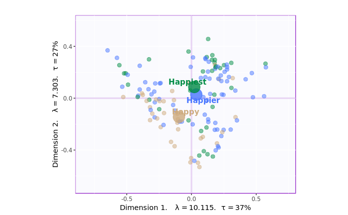

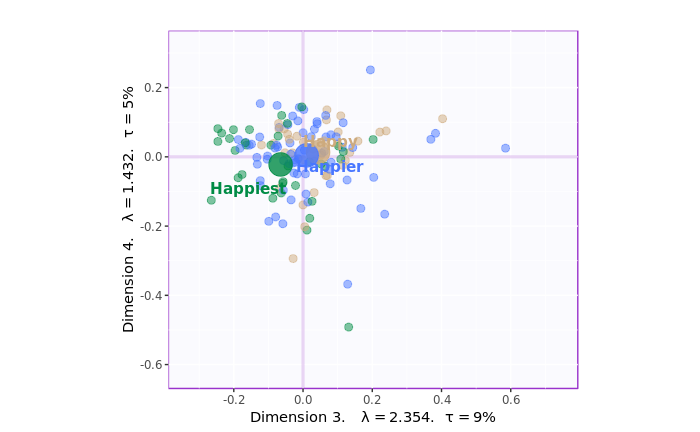

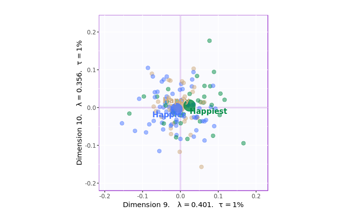

```r
for(i in c(1,3,5,7, 9)) {
  axis1 = i
  axis2 = i+1

  country_factor_map <- PTCA4CATA::createFactorMap(country_env_pca$ExPosition.Data$fi, title='',
                                                 col.points = country_env_pca$Plotting.Data$fi.col,
                                                 col.labels = country_env_pca$Plotting.Data$fi.col,
                                                 axis1 = axis1,
                                                 axis2 = axis2,
                                                 display.labels = FALSE)

country_factor_map_mean <- PTCA4CATA::createFactorMap(country_env_pca_mean,
                                                 col.points = unique(country_env_pca$Plotting.Data$fi.col),
                                                 col.labels = unique(country_env_pca$Plotting.Data$fi.col),
                                                 axis1 = axis1,
                                                 axis2 = axis2,
                                                 display.labels = TRUE,
                                                 cex = 8,alpha.points = 0.8)

country_label4Map <- PTCA4CATA::createxyLabels.gen(axis1,axis2,lambda = country_env_pca$ExPosition.Data$eigs, tau = country_env_pca$ExPosition.Data$t)



country_map = country_factor_map$zeMap + country_label4Map + country_factor_map_mean$zeMap_dots + country_factor_map_mean$zeMap_text
print(country_map)
}
```

```r
#country_map_mean = country_factor_map_mean$zeMap
#print(country_map_mean)
```

## Loadings

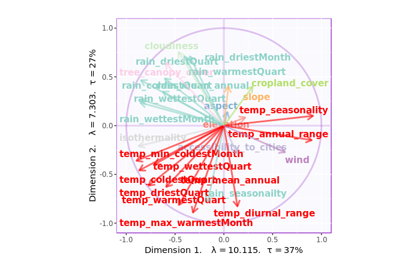

```r
axis1 = 1
axis2 = 2

col_palate = brewer.pal(n = 12, name='Set3')

col4J = vector('list', nrow(country_env_pca$ExPosition.Data$fj))
col4J[grep('rain',rownames(country_env_pca$ExPosition.Data$fj))] = col_palate[1]
col4J[grep('temp',rownames(country_env_pca$ExPosition.Data$fj))] = 'red' #col_palate[2]
col4J[sapply(col4J, 'is.null')] = col_palate[3:11]

loadings_2 <- cor(country_env_df_for_pca, country_env_pca$ExPosition.Data$fi)

loadings_map <- PTCA4CATA::createFactorMap(loadings_2,
                        col.points = col4J,
                        col.labels = col4J,
                        axis1=axis1,
                        axis2=axis2,
                        constraints = list(minx = -1, miny = -1, maxx = 1 , maxy = 1))

country_label4Map <- PTCA4CATA::createxyLabels.gen(axis1,axis2,lambda = country_env_pca$ExPosition.Data$eigs, tau = country_env_pca$ExPosition.Data$t)

corr_map <- loadings_map$zeMap_background  +  country_label4Map + PTCA4CATA::addCircleOfCor() +
            loadings_map$zeMap_text +
            PTCA4CATA::addArrows(loadings_2, color = col4J)

print(corr_map)
```

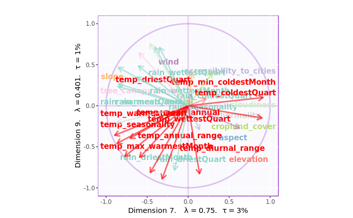

```r
axis1 = 7
axis2 = 9

col_palate = brewer.pal(n = 12, name='Set3')

col4J = vector('list', nrow(country_env_pca$ExPosition.Data$fj))
col4J[grep('rain',rownames(country_env_pca$ExPosition.Data$fj))] = col_palate[1]
col4J[grep('temp',rownames(country_env_pca$ExPosition.Data$fj))] = 'red' #col_palate[2]
col4J[sapply(col4J, 'is.null')] = col_palate[3:11]

loadings_2 <- cor(country_env_df_for_pca, country_env_pca$ExPosition.Data$fi)

loadings_map <- PTCA4CATA::createFactorMap(loadings_2,
                        col.points = col4J,
                        col.labels = col4J,
                        axis1=axis1,
                        axis2=axis2,
                        constraints = list(minx = -1, miny = -1, maxx = 1 , maxy = 1))

country_label4Map <- PTCA4CATA::createxyLabels.gen(axis1,axis2,lambda = country_env_pca$ExPosition.Data$eigs, tau = country_env_pca$ExPosition.Data$t)

corr_map <- loadings_map$zeMap_background  +  country_label4Map + PTCA4CATA::addCircleOfCor() +
            loadings_map$zeMap_text +
            PTCA4CATA::addArrows(loadings_2, color = col4J)

print(corr_map)
```

## Summary

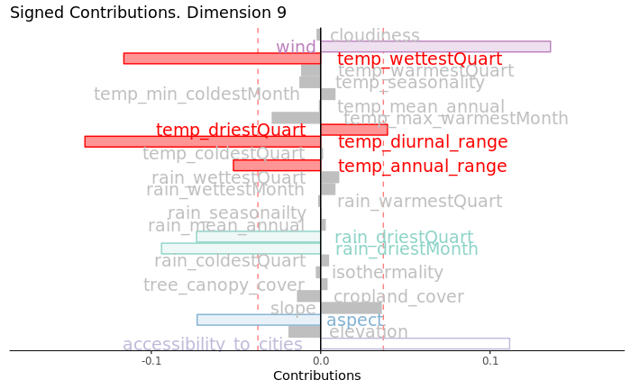

```r
create.ctrPlot <- function(res, axis = 1, col = NULL, set = 'J', ...)
  { if (set == 'I') {
    ctr.s <- res$ExPosition.Data$ci[,axis] * sign(res$ExPosition.Data$fi[,axis])
    } else {
      ctr.s <- res$ExPosition.Data$cj[,axis] * sign(res$ExPosition.Data$fj[,axis])
      }
  zebars <- PrettyBarPlot2(ctr.s,
                           threshold = 1 / length(ctr.s),
                           color4bar = gplots::col2hex(col), # we need hex code
                           main = paste0('Signed Contributions. Dimension ',axis),
                           ylab = 'Contributions',
                           ylim = c(1.2*min(ctr.s), 1.2*max(ctr.s) ), ...)
  return(zebars)
  } # end of function create.ctrPlot


e1.ctrJ <- create.ctrPlot(country_env_pca, axis = 9,
                          font.size = 5, col = col4J,
                          horizontal = FALSE)

print(e1.ctrJ)
```

```r
NA
NA
```

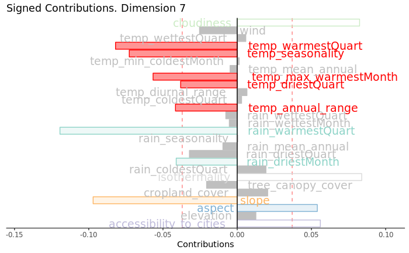

```r
e1.ctrJ <- create.ctrPlot(country_env_pca, axis = 7,
                          font.size = 5, col = col4J,
                          horizontal = FALSE)

print(e1.ctrJ)
```

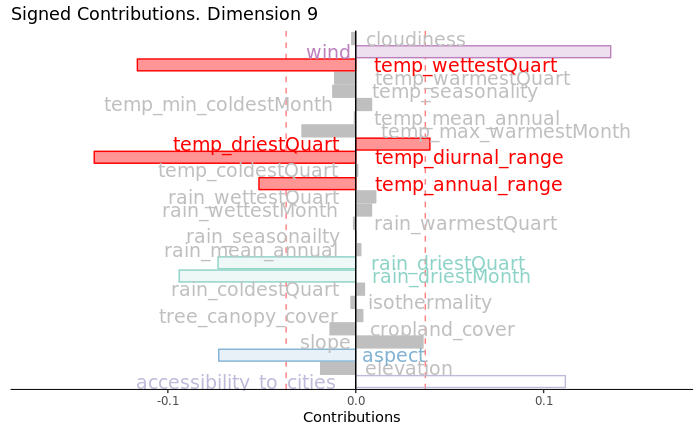

```r
e1.ctrJ <- create.ctrPlot(country_env_pca, axis = 9,
                          font.size = 5, col = col4J,
                          horizontal = FALSE)

print(e1.ctrJ)
```